# Relatório 03 - Medidas de Posição e Dispersão

## Boxplot do número de faltas

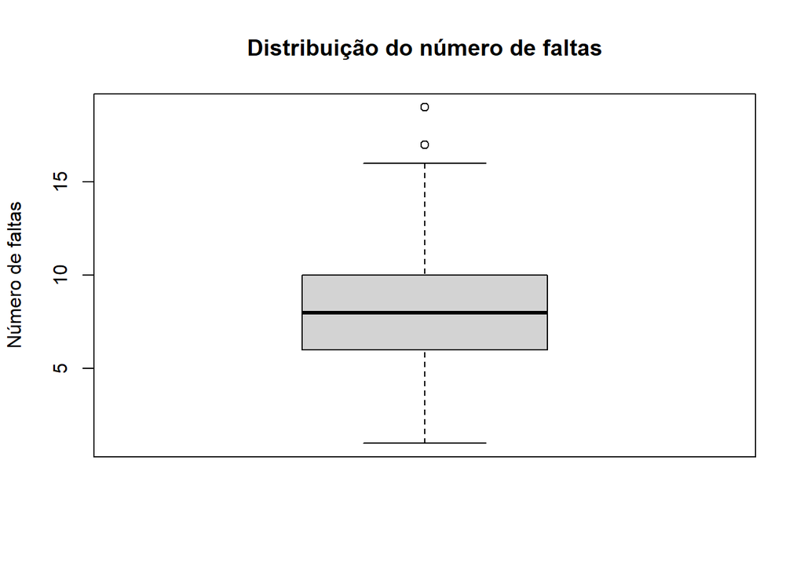

```r
boxplot(
  dados_alunos$faltas,
  main = "Distribuição do número de faltas",
  ylab = "Número de faltas"
)
```

```r
sort(unique(boxplot.stats(dados_alunos$faltas)$out))
```

```
## [1] 17 19
```

### Interpretação

Para o número de faltas, a mediana foi **8**, o primeiro quartil **6** e o terceiro quartil **10**, resultando em amplitude interquartil igual a **4**.

Assim, aproximadamente metade dos estudantes possui entre 6 e 10 faltas.

O boxplot identificou valores elevados de **17 e 19 faltas** como possíveis valores discrepantes. Apesar desses valores extremos, média e mediana permaneceram muito próximas, indicando que seu impacto sobre o centro da distribuição é limitado.

## Comparação das notas segundo o acesso à internet

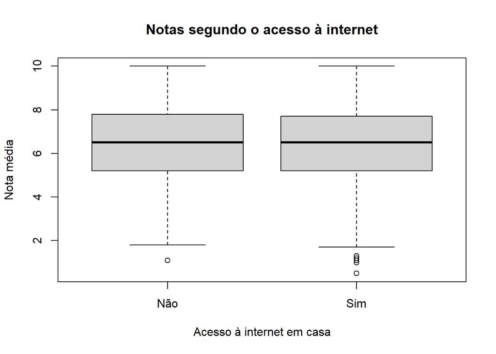

```r
boxplot(
  nota_media ~ acesso_internet,
  data = dados_alunos,
  main = "Notas segundo o acesso à internet",
  xlab = "Acesso à internet em casa",
  ylab = "Nota média"
)
```

### Interpretação

Os boxplots dos alunos com e sem acesso à internet apresentam centros e dispersões muito semelhantes. As medianas são iguais a **6,5**, e as amplitudes interquartis também são próximas.

Visualmente, portanto, não há uma diferença expressiva no comportamento das notas entre os dois grupos.

## Comparação das notas segundo a escolaridade da mãe

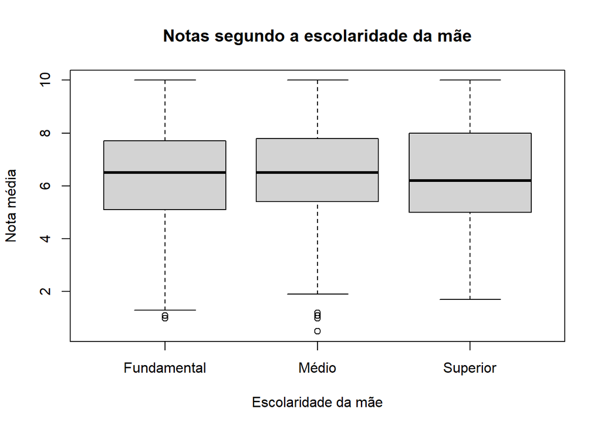

```r
boxplot(
  nota_media ~ escolaridade_mae,
  data = dados_alunos,
  main = "Notas segundo a escolaridade da mãe",
  xlab = "Escolaridade da mãe",
  ylab = "Nota média"
)
```

### Interpretação

As distribuições apresentam centros relativamente próximos. Os grupos Fundamental e Médio possuem mediana igual a **6,5**, enquanto o grupo Superior apresenta mediana igual a **6,2**.

O grupo Superior apresenta maior dispersão, com amplitude interquartil igual a **3,0** e coeficiente de variação de aproximadamente **32,01%**.

Dessa forma, os gráficos reforçam que uma comparação baseada apenas nas médias não é suficiente para caracterizar completamente os grupos.

## Comparação das notas segundo o turno

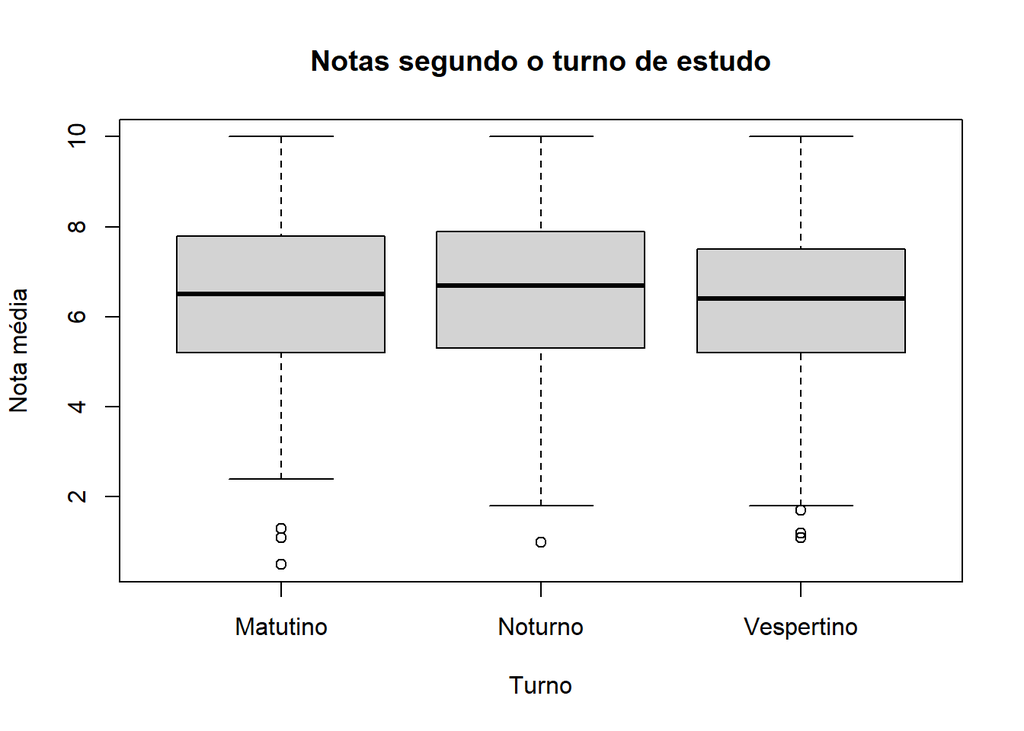

```r
boxplot(
  nota_media ~ turno,
  data = dados_alunos,
  main = "Notas segundo o turno de estudo",
  xlab = "Turno",
  ylab = "Nota média"
)
```

### Interpretação

As distribuições das notas dos três turnos apresentam grande sobreposição.

As notas médias são aproximadamente **6,46** no Matutino, **6,58** no Noturno e **6,34** no Vespertino. As medianas também são próximas.

Portanto, do ponto de vista descritivo, não se observa uma separação acentuada entre os grupos segundo o turno de estudo.

# Tabela estatística

A seguir é apresentada uma tabela-síntese com as principais medidas de posição e dispersão das variáveis `faltas` e `nota_media`.

```r
tabela_sintese <- data.frame(
  Medida = c(
    "Mínimo",
    "Q1",
    "Média",
    "Mediana",
    "Q3",
    "Máximo",
    "Amplitude",
    "AIQ",
    "Variância",
    "Desvio-padrão",
    "Coeficiente de variação (%)"
  ),
  Faltas = c(
    min(dados_alunos$faltas),
    as.numeric(quantile(dados_alunos$faltas, 0.25)),
    mean(dados_alunos$faltas),
    median(dados_alunos$faltas),
    as.numeric(quantile(dados_alunos$faltas, 0.75)),
    max(dados_alunos$faltas),
    max(dados_alunos$faltas) - min(dados_alunos$faltas),
    IQR(dados_alunos$faltas),
    var(dados_alunos$faltas),
    sd(dados_alunos$faltas),
    sd(dados_alunos$faltas) / mean(dados_alunos$faltas) * 100
  ),
  Nota_Media = c(
    min(dados_alunos$nota_media),
    as.numeric(quantile(dados_alunos$nota_media, 0.25)),
    mean(dados_alunos$nota_media),
    median(dados_alunos$nota_media),
    as.numeric(quantile(dados_alunos$nota_media, 0.75)),
    max(dados_alunos$nota_media),
    max(dados_alunos$nota_media) - min(dados_alunos$nota_media),
    IQR(dados_alunos$nota_media),
    var(dados_alunos$nota_media),
    sd(dados_alunos$nota_media),
    sd(dados_alunos$nota_media) / mean(dados_alunos$nota_media) * 100
  )
)

knitr::kable(
  tabela_sintese,
  digits = 2,
  caption = "Síntese das medidas estatísticas"
)
```

Síntese das medidas estatísticas

| Medida | Faltas | Nota_Media |
| --- | --- | --- |
| Mínimo | 1.00 | 0.50 |
| Q1 | 6.00 | 5.20 |
| Média | 8.01 | 6.44 |
| Mediana | 8.00 | 6.50 |
| Q3 | 10.00 | 7.70 |
| Máximo | 19.00 | 10.00 |
| Amplitude | 18.00 | 9.50 |
| AIQ | 4.00 | 2.50 |
| Variância | 7.83 | 3.54 |
| Desvio-padrão | 2.80 | 1.88 |
| Coeficiente de variação (%) | 34.93 | 29.21 |

### Análise da tabela

As medidas de posição mostram que as duas distribuições apresentam média e mediana bastante próximas.

Para as faltas, a média foi **8,01** e a mediana **8**. Para as notas, a média foi **6,44** e a mediana **6,5**.

Entretanto, as medidas de dispersão mostram diferenças importantes. O coeficiente de variação das faltas foi aproximadamente **34,93%**, enquanto para as notas foi aproximadamente **29,21%**.

Portanto, quando a variabilidade é analisada em relação ao tamanho da média de cada variável, **as faltas apresentam maior dispersão relativa**.

# Discussão dos resultados

## Média versus mediana

Se fosse necessário escolher apenas uma medida para representar o comportamento típico das notas dos alunos, seria razoável utilizar a **mediana**.

Embora a média, igual a aproximadamente **6,44**, e a mediana, igual a **6,5**, sejam muito próximas, existem algumas notas extremamente baixas identificadas pelo boxplot. A mediana possui a vantagem de ser menos sensível a esses valores extremos.

Isso não significa que a média seja inadequada. Neste banco de dados, ambas fornecem uma representação semelhante do centro da distribuição. A escolha da mediana, entretanto, oferece maior resistência à influência de valores discrepantes.

## O efeito da variabilidade

A comparação entre grupos demonstra por que a análise apenas das médias pode produzir uma descrição incompleta.

Por exemplo, os grupos de escolaridade da mãe apresentam médias relativamente próximas. Entretanto, o grupo Superior apresentou desvio-padrão de aproximadamente **2,05** e coeficiente de variação de aproximadamente **32,01%**, superiores aos observados nos grupos Fundamental e Médio.

Portanto, dois grupos podem apresentar centros semelhantes e, ao mesmo tempo, possuir graus diferentes de dispersão.

As medidas de variabilidade permitem identificar essas diferenças e complementam as informações fornecidas pela média.

## Medida mais adequada em diferentes situações

**a) Identificar o desempenho médio dos alunos**

A medida mais adequada é a **média aritmética**, pois utiliza todas as notas e representa o desempenho médio do conjunto.

**b) Identificar o desempenho típico quando existem valores extremos**

A **mediana** é mais adequada, pois apresenta menor sensibilidade a valores muito altos ou muito baixos.

**c) Avaliar a dispersão das notas**

O **desvio-padrão** é uma medida adequada porque expressa a dispersão na mesma unidade das notas. A amplitude interquartil também é útil quando se deseja uma medida menos afetada por extremos.

**d) Comparar a variabilidade de duas variáveis com escalas diferentes**

O **coeficiente de variação** é mais adequado, pois relaciona o desvio-padrão à média e apresenta a dispersão em termos percentuais.

**e) Identificar a posição de um aluno em relação aos demais**

Os **percentis** são particularmente úteis, pois indicam a posição relativa de uma observação dentro da distribuição.

## Síntese e reflexão

### 1. Qual medida de posição melhor representa as notas médias dos alunos?

A **mediana**, igual a **6,5**, é uma boa representação do comportamento típico das notas, principalmente porque há alguns valores baixos considerados discrepantes.

Entretanto, como a média é aproximadamente **6,44**, muito próxima da mediana, ambas fornecem informações coerentes sobre o centro da distribuição.

### 2. Qual medida melhor representa o número de faltas?

A mediana, igual a **8**, representa adequadamente o número típico de faltas e possui a vantagem de não ser fortemente influenciada pelos poucos valores elevados de 17 e 19 faltas.

Novamente, a média de **8,01** é praticamente igual à mediana, indicando estabilidade do centro da distribuição.

### 3. Qual variável apresenta maior variabilidade relativa?

O número de faltas apresenta maior variabilidade relativa.

Seu coeficiente de variação foi aproximadamente **34,93%**, enquanto o coeficiente de variação das notas foi aproximadamente **29,21%**.

### 4. A análise da dispersão modificou conclusões baseadas apenas na média?

Sim. As medidas de dispersão permitiram identificar diferenças que não seriam percebidas observando apenas as médias.

Na comparação segundo a escolaridade materna, por exemplo, os grupos possuem médias relativamente semelhantes, porém o grupo Superior apresentou maior variabilidade nas notas.

Portanto, duas distribuições podem possuir centros semelhantes e comportamentos diferentes quanto à dispersão.

### 5. Quais diferenças foram observadas entre os grupos?

Os grupos com e sem acesso à internet apresentaram valores muito semelhantes tanto nas medidas de posição quanto nas medidas de dispersão.

Na comparação segundo a escolaridade da mãe, as médias também foram próximas, mas o grupo Superior apresentou maior variabilidade.

Em relação às faltas segundo o turno, as médias e medianas foram praticamente iguais, embora o turno Vespertino tenha apresentado uma dispersão ligeiramente maior.

### 6. Quais cuidados devem ser tomados ao interpretar essas diferenças?

Diferenças numéricas pequenas não devem ser automaticamente consideradas relevantes.

Também é importante observar o tamanho dos grupos, possíveis valores extremos e diferentes medidas de dispersão.

Além disso, as análises realizadas neste relatório são predominantemente descritivas e mostram como os dados se comportam, mas não demonstram relações causais.

### 7. Quais limitações devem ser consideradas antes de atribuir o desempenho às características sociofamiliares?

A escolaridade da mãe e o acesso à internet representam apenas algumas das muitas características que podem estar relacionadas ao desempenho escolar.

Outros fatores, como renda familiar, hábitos de estudo, motivação, frequência, condições escolares, acompanhamento familiar e características individuais, não foram considerados.

Além disso, diferenças observadas entre grupos representam **descrições estatísticas e possíveis associações**, e não evidência de que uma variável seja responsável pela outra.

# Conclusões

O Relatório 03 permitiu aprofundar a análise descritiva do banco de dados por meio de medidas de posição e de dispersão.

A análise mostrou que o número médio de faltas foi aproximadamente **8,01**, com mediana igual a **8**, enquanto a nota média foi aproximadamente **6,44**, com mediana igual a **6,5**.

Em ambas as variáveis, a proximidade entre média e mediana indica que as medidas centrais apresentam resultados semelhantes.

Entretanto, as medidas de dispersão acrescentaram informações importantes. O coeficiente de variação mostrou que o número de faltas possui maior variabilidade relativa que as notas.

As comparações entre subgrupos também mostraram a importância de analisar simultaneamente centro e dispersão. Grupos com médias semelhantes podem apresentar diferentes graus de variabilidade.

Dessa forma, a análise reforça que uma descrição estatística adequada não deve depender de uma única medida, mas da utilização conjunta de medidas de posição, medidas de dispersão e representações gráficas.

# Limitações da análise

O banco de dados utilizado foi construído para simular uma situação de pesquisa em uma escola pública e possui finalidade pedagógica. Dessa forma, os resultados não devem ser generalizados diretamente para outras escolas ou para toda a população estudantil.

Além disso, o banco contém apenas cinco variáveis, não contemplando toda a complexidade dos fatores relacionados ao desempenho acadêmico.

As análises realizadas neste relatório são essencialmente descritivas. Portanto, diferenças entre médias, medianas ou medidas de dispersão não permitem estabelecer relações de causa e efeito.

Também é necessário considerar que os grupos possuem tamanhos diferentes e que alguns valores extremos podem influenciar determinadas medidas.

Assim, os resultados devem ser interpretados como uma descrição do banco analisado, distinguindo claramente **descrição estatística, associação e causalidade**.

# Código R utilizado

Os principais procedimentos estatísticos utilizados no relatório foram realizados com funções da linguagem R. Entre os principais comandos empregados estão:

```r
# Importação
dados_alunos <- read.table(
  "dados_alunos.csv",
  header = TRUE,
  sep = ";",
  dec = ",",
  stringsAsFactors = FALSE
)

# Medidas de posição
mean(dados_alunos$faltas)
median(dados_alunos$faltas)
quantile(dados_alunos$faltas)

mean(dados_alunos$nota_media)
median(dados_alunos$nota_media)
quantile(dados_alunos$nota_media)

# Medidas de dispersão
var(dados_alunos$faltas)
sd(dados_alunos$faltas)
IQR(dados_alunos$faltas)

var(dados_alunos$nota_media)
sd(dados_alunos$nota_media)
IQR(dados_alunos$nota_media)

# Coeficiente de variação
sd(dados_alunos$faltas) / mean(dados_alunos$faltas) * 100
sd(dados_alunos$nota_media) / mean(dados_alunos$nota_media) * 100

# Comparações por grupos
by(
  dados_alunos$nota_media,
  dados_alunos$acesso_internet,
  resumo_estatistico
)

by(
  dados_alunos$nota_media,
  dados_alunos$escolaridade_mae,
  resumo_estatistico
)

by(
  dados_alunos$faltas,
  dados_alunos$turno,
  resumo_estatistico
)

# Representações gráficas
boxplot(dados_alunos$nota_media)
boxplot(dados_alunos$faltas)

boxplot(nota_media ~ acesso_internet, data = dados_alunos)
boxplot(nota_media ~ escolaridade_mae, data = dados_alunos)
boxplot(nota_media ~ turno, data = dados_alunos)
```